# 第9回 発展 固有顔の向きに、顔を動かす

平均の顔 ± 固有顔

## 固有顔は、ずれの向き

- 固有顔は、「平均の顔から、どの向きにずれるか」
- 平均の顔に、固有顔を足したり引いたりすると？

## 動かす量の単位

- その向きの散らばりの大きさ、標準偏差 √λを単位にする
- −2から ＋2まで動かす

## 明るさの目盛りを、固定する

- `imshow`は、ふつう画像ごとに、暗い所を黒、明るい所を白に伸ばす
- それだと、顔全体が明るくなっても、見た目が変わらない
- `vmin=0, vmax=1`：どの画像も、0（黒）〜1（白）の同じ目盛りで

## 動かしてみる

```python
mean_face = X.mean(axis=0)
steps = [-2, -1, 0, 1, 2]
fig, axes = plt.subplots(3, 5, figsize=(10, 6.5))
for r in range(3):                                   # 固有顔1〜3
    sd = np.sqrt(pca.explained_variance_[r])         # その向きの標準偏差
    for c, s in enumerate(steps):
        v = mean_face + s * sd * pca.components_[r]
        ax = axes[r, c]
        ax.imshow(v.reshape(64, 64), cmap='gray', vmin=0, vmax=1)
        ax.set_title(f'固有顔{r + 1} {s:+d}'); ax.axis('off')
plt.tight_layout(); plt.show()
```

## 結果

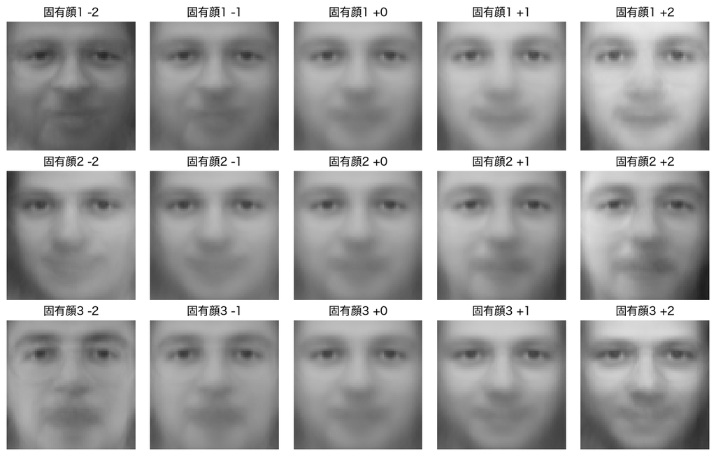

## 真ん中は、平均の顔

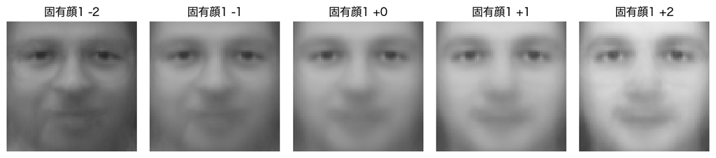

- 0の列は、どれも平均の顔
- 固有顔1は、顔全体の明るさが変わる（目盛りを固定したので見える）

## 2行目・3行目は、光の向き

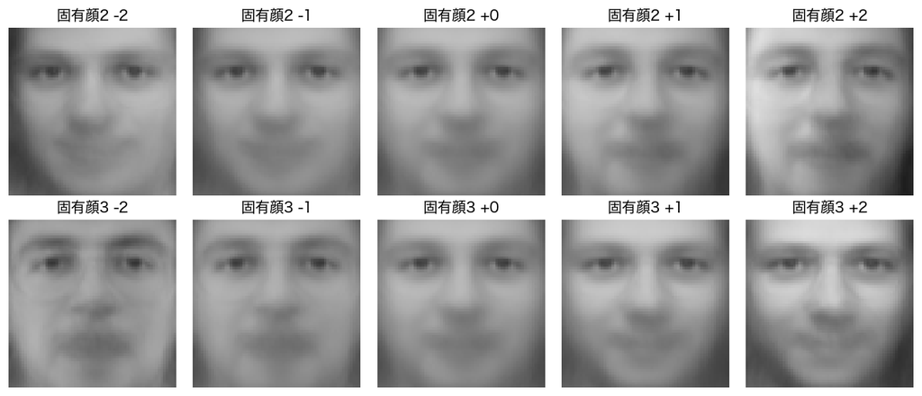

- 固有顔2は左右から、3は上下からの光の当たり方が変わる
- 得点は、「この向きに、どれだけずれているか」の数

## 符号には、意味がない

- 固有顔の符号は、計算の都合で決まる
- ＋と−のどちらが明るいかに、意味はない

## 試すなら

- `range(3)`を`range(3, 6)`に変えて、固有顔4〜6を動かす
- 後ろほど、目元や口元の細かい動きになる